# Flacons cosmétiques

S. Jaubert

04/02/2021

#### **Présentation de l’étude**

Une entreprise pharmaceutique contrôle sa production par échantillonage (49 flacons) en mesurant le volume de médicament (poudre) contenu dans un flacon.

Ce n’est pas réellement le volume de médicament (poudre) qui est mesuré mais plutôt la masse du flacon rempli : le volume se déduit ensuite à l’aide de la densité du médicament (poudre) et de la masse d’un flacon vide.

La réglementation en vigueur tolère un pourcentage de la production inférieur à 5% de produit finis entre la zone T1- et T2-. **Le poids moyen de produit pour l’ensemble d’une production doit être supérieur au poids cible (valeur affichée sur un flacon). Par contre, aucun produit ne doit se situer en dessous de la zone T2-.**

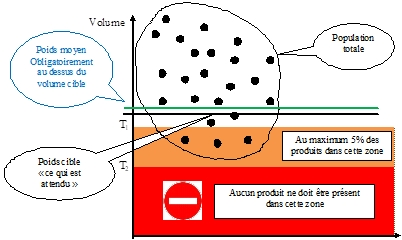

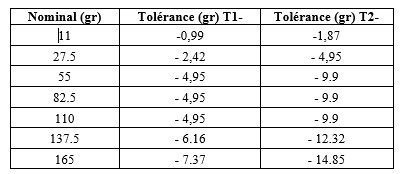

#### 1)

```r
(FV<-read.csv(file = "flacons_vides.csv")$x)
```

```
##  [1] 20.03 20.24 19.99 20.22 20.21 20.29 20.02 20.28 19.87 20.03 20.21 20.05
## [13] 20.30 20.33 20.85 20.87 20.02 20.26 20.85 20.24 20.06 20.76 20.27 20.08
## [25] 19.96 20.09 20.76 20.66 20.06 21.01 20.12 20.07 20.11 20.16 19.94 20.26
## [37] 20.01 20.92 19.94 20.24 19.82 20.32 20.26 20.38 20.24
```

Masse des flacons rouges et bleus :

```r
FR<-read.csv(file = "flacons_rouges.csv")$x
FB<-read.csv(file = "flacons_bleus.csv")$x
mat<-cbind(FR=FR,FB=FB)
```

Comparons les données :

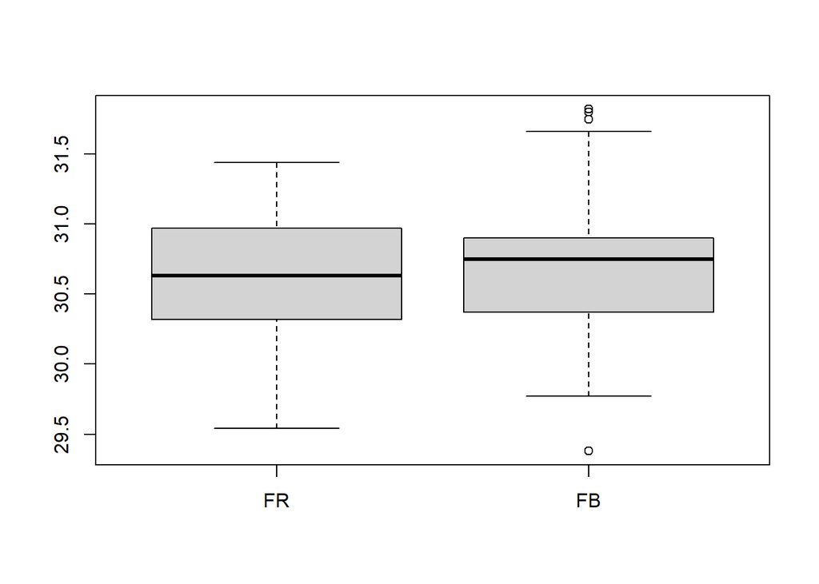

```r
boxplot(FR,FB,names = c("FR","FB"))
```

Les flacons vides suivent-ils une loi normale ?

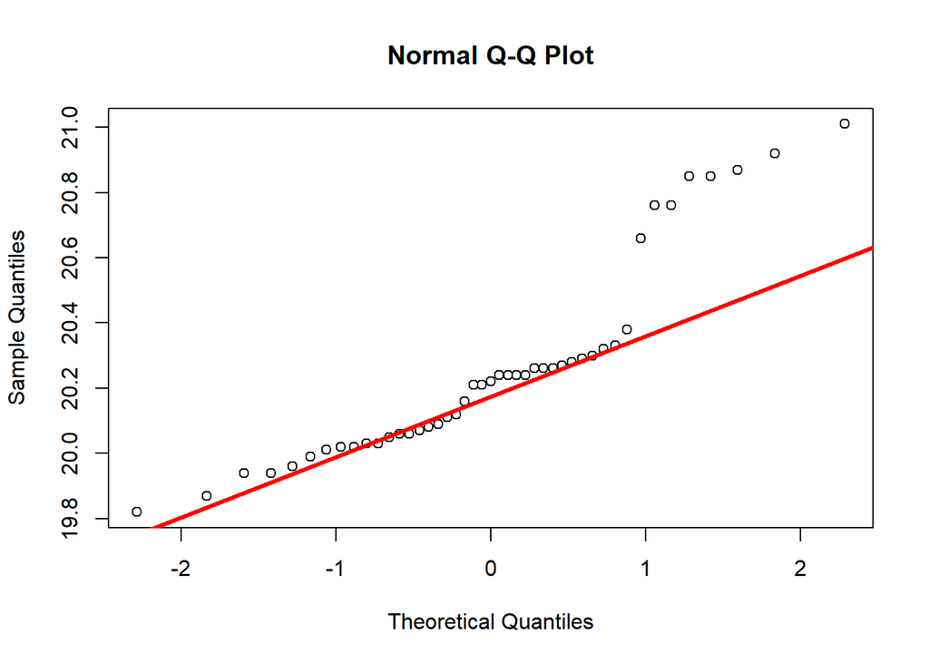

```r
qqnorm(FV);qqline(FV,col="red",lwd=3)
```

Visuellement la normalité de la distribution n’est pas acquise. Un test de normalité va trancher :

```r
shapiro.test(FV)
```

```
##
##  Shapiro-Wilk normality test
##
## data:  FV
## W = 0.86397, p-value = 8.551e-05
```

Avec une telle p-value nous ne pouvons que rejeter l’hypothèse de normalité…

Pour les bleus et rouges nous avons :

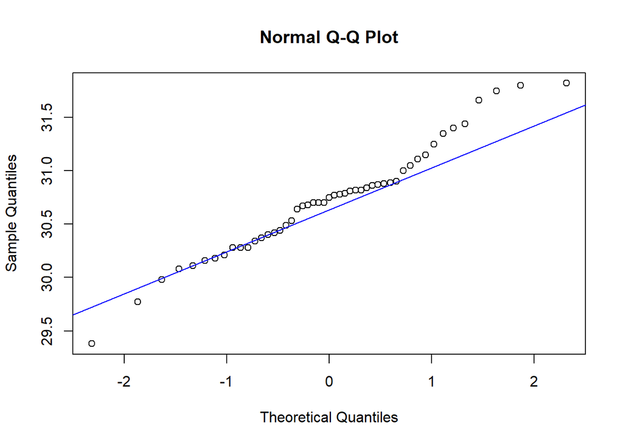

```r
qqnorm(FB);qqline(FB,col="blue")
```

```r
shapiro.test(FB)
```

```
##
##  Shapiro-Wilk normality test
##
## data:  FB
## W = 0.97745, p-value = 0.4635
```

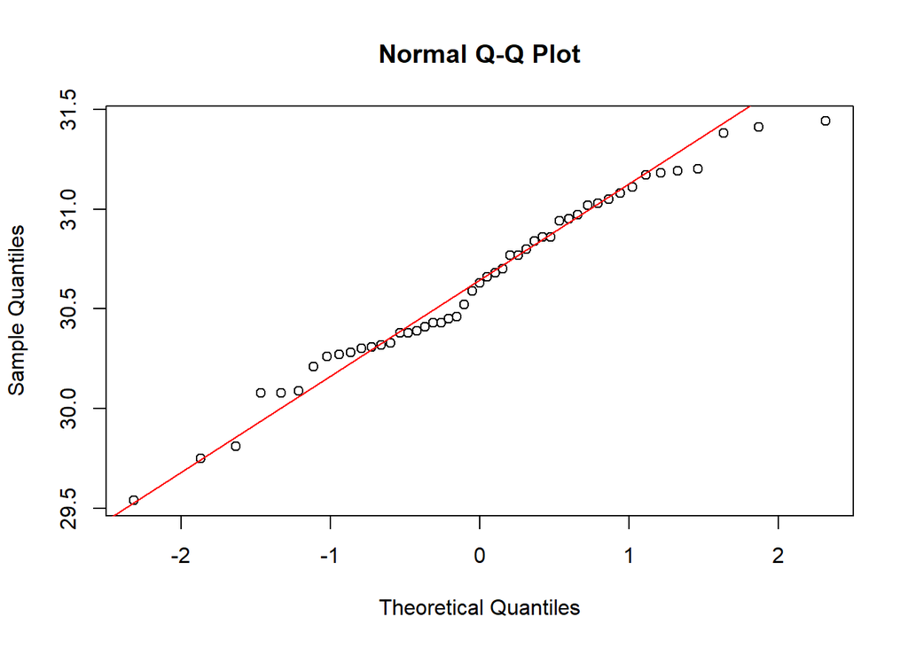

```r
qqnorm(FR);qqline(FR,col="red")
```

```r
shapiro.test(FR)
```

```
##
##  Shapiro-Wilk normality test
##
## data:  FR
## W = 0.97853, p-value = 0.5053
```

L’hypothèse de normalité est conservée pour les deux échantillons.

#### 2)

Histogramme des données :

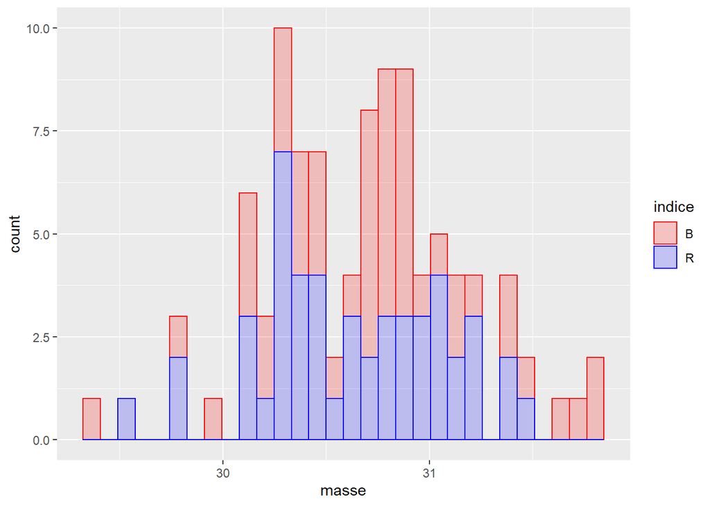

```r
dat <- data.frame(masse=c(FR,FB),indice = rep(c('R','B'),c(49,49)))
library(ggplot2)

p<-ggplot(dat,aes(x=masse))
p + geom_histogram(aes(color = indice, fill = indice),alpha = 0.2,) +
  scale_fill_manual(values = c("RED", "BLUE")) +
  scale_color_manual(values = c("RED", "BLUE"))
```

Moyennes et écart-types des masses de médicament mesurées pour les deux échantillons :

```r
(moy_ech<-apply(mat,2,mean)-mean(FV))
```

```
##       FR       FB
## 10.36864 10.46232
```

```r
(sd_ech<-apply(mat,2,sd))
```

```
##        FR        FB
## 0.4425648 0.5163776
```

**Cette moyenne est en dessous de la masse cible qui est de 11 gr**

#### 3)

Soit une densité (gr/ml):

```r
moy_ech/10
```

```
##       FR       FB
## 1.036864 1.046232
```

#### 4)

Les intervalles de confiance des moyennes au niveau de confiance de 98% sont :

Flacons rouges

```r
t.test(FR, conf.level = 0.98)
```

```
##
##  One Sample t-test
##
## data:  FR
## t = 484.44, df = 48, p-value < 2.2e-16
## alternative hypothesis: true mean is not equal to 0
## 98 percent confidence interval:
##  30.47560 30.77991
## sample estimates:
## mean of x
##  30.62776
```

Flacons bleus :

```r
t.test(FB, conf.level = 0.98)
```

```
##
##  One Sample t-test
##
## data:  FB
## t = 416.46, df = 48, p-value < 2.2e-16
## alternative hypothesis: true mean is not equal to 0
## 98 percent confidence interval:
##  30.54390 30.89896
## sample estimates:
## mean of x
##  30.72143
```

#### 5)

Le pourcentage de produit compris dans la zone T2 et T1 est pour les deux échantillons :

Pour les rouges

```r
pnorm(11-0.99,mean = moy_ech[1],sd = sd_ech[1])-pnorm(11-1.87,mean = moy_ech[1],sd = sd_ech[1])
```

```
## [1] 0.2062972
```

Pour les bleus

```r
pnorm(11-0.99,mean = moy_ech[2],sd = sd_ech[2])-pnorm(11-1.87,mean = moy_ech[2],sd = sd_ech[2])
```

```
## [1] 0.1855922
```

#### Conclusion

Nous ne respectons pas la norme en vigueur car le poids moyen est en dessous des 11gr et de plus pour les deux échantillons nous obtenons une probabilité supérieure à 5% de produit dans la zone T2 T1.